# LSTAT2020 : Travail R

Deveaux Nathan et Piron Louis-David

2024-12-07

# Opérations prémiliminaires.

Pour assurer la reproducibilité des résultats, veillez à donner le chemin d’accès vers le dossier contenant votre base de donnée, ainsi que le nom de la base de donnée elle même, au format csv.

A noter que pour le chemin d’accès, les `\` doivent être remplacés par des `/`.

```r
#A MODIFIER AVANT DE LANCER LE SCRIPT#################################################

chemin_acces <- "C:/Users/louis/Desktop/Master 1/Q1/Logiciels et programmation statistiques de base/Projet"
fichier <- "cyclo.csv"
```

# PARTIE A : Analyse.

## Question 1.

Commençons par modifier le répertoire courant (*working directory*) et par importer les données :

```r
setwd(chemin_acces)

data_cyclo <- read.csv(file.path(chemin_acces,fichier),header = TRUE,sep = ",",dec = ".")
```

## Question 2.

Pour faire une table de indiquant le nombre de fichiers que nous avons par cycliste, dans un premier temps, il faut construire une table de contïngence entre les variables `file` et `user`. Cette table de nous donnera le nombre de fois où un cycliste `user` apparaît dans un fichier `file`.

```r
table_cycl_fich <- table(data_cyclo$user, data_cyclo$file)
```

Pour déterminer le nombre de fichiers par cycliste,il suffit maintenant de compter le nombre d’éléments non-nuls pour chaque ligne de la table :

```r
nb_fichiers_par_cycliste <- rowSums(table_cycl_fich > 0)
nb_fichiers_par_cycliste
```

```
## user 0 user 1 user 2 user 3
##     32     72     15     88
```

## Question 3.

Pour sélectionner un fichier au hasard, nous avons d’abbord stocké dans la variable `fichiers` la liste des différents fichiers existant dans notre jeu de donnée, au moyen de la fonction `unique()`. Ensuite,nous avons utilisé la commande `sample(fichiers,1)`, pour choisir aléatoirement un des fichiers. Les observations correspondant à ce fichier on ensuite été stockées dans la variable `echantillon`.

```r
set.seed(2003)

fichiers <- unique(data_cyclo$file)

fichier_choisi <- sample(fichiers,1)

echantillon <- data_cyclo[data_cyclo$file == fichier_choisi,]

head(echantillon)
```

```
##        X                 timestamp hr po   ele speed time_s   user
## 679258 0 2015-04-12 06:22:33+00:00 86  1 -16.2 1.026      0 user 1
## 679259 1 2015-04-12 06:22:34+00:00 86  1 -16.2 1.026      1 user 1
## 679260 2 2015-04-12 06:22:35+00:00 87  0  -5.6 0.000      2 user 1
## 679261 3 2015-04-12 06:22:36+00:00 87  0  -6.2 0.448      3 user 1
## 679262 4 2015-04-12 06:22:37+00:00 87  0  -6.8 0.448      4 user 1
## 679263 5 2015-04-12 06:22:38+00:00 87  7  -7.4 0.448      5 user 1
##                 file
## 679258 743963393.csv
## 679259 743963393.csv
## 679260 743963393.csv
## 679261 743963393.csv
## 679262 743963393.csv
## 679263 743963393.csv
```

La commande `set.seed()` est là pour assurer la reproducibilité des résultats de notre rapport.

## Question 4.

Pour calculer la moyenne, l’écart-type, le minimum et le maximum de la variable `hr`, nous avons simplement utilisé les fonctions préimplémentées `mean()`,`sd()`,`min()` et `max()`. Pour ne pas considérer les valeurs manquantes dans nos calculs, nous avons ajouté l’argument `na.rm = TRUE`.

```r
data.frame(
  Moyenne = round(mean(echantillon[,"hr"], na.rm = TRUE), 2),
  Ecart_Type = round(sd(echantillon[,"hr"], na.rm = TRUE), 2),
  Minimum = round(min(echantillon[,"hr"], na.rm = TRUE), 2),
  Maximum = round(max(echantillon[,"hr"], na.rm = TRUE), 2)
)
```

```
##   Moyenne Ecart_Type Minimum Maximum
## 1  108.82       6.53      86     133
```

## Question 5.

Ici, nous suivons la même logique qu’à la question précédente à la différence près que nous utilisons maintenant `sapply()` pour appliquer les fonctions mean, sd, min et max aux colonnes spécifiées (`variables`) d’un jeu de données (`data`). Les résultats sont d’abord stockés sous forme d’un data.frame dans la variables `résultat`. Ils sont ensuite transposés afin d’afficher les statistiques en lignes et les variables en colonnes.

La fonction fait aussi appel à `cat()` et `print()` pour formater et afficher les résultats de manière lisible dans la console.

```r
calculer_statistiques <- function(data, variables) {

  resultats <- data.frame(
    Moyenne = round(sapply(data[variables], mean, na.rm = TRUE), 2),
    Ecart_Type = round(sapply(data[variables], sd, na.rm = TRUE), 2),
    Minimum = round(sapply(data[variables], min, na.rm = TRUE), 2),
    Maximum = round(sapply(data[variables], max, na.rm = TRUE), 2)
  )

  resultats <- t(resultats) #On transpose le résultat pour avoir les statisitques
                            # en lignes et les noms de variables en colonnes.

  cat("\nStatistiques descriptives :\n")
  cat("--------------------------------------------------\n")
  print(resultats)
  cat("--------------------------------------------------\n")
}

#Exemple :

calculer_statistiques(echantillon,c("po","speed","hr"))
```

```
##
## Statistiques descriptives :
## --------------------------------------------------
##                po speed     hr
## Moyenne     84.97  5.52 108.82
## Ecart_Type  40.61  1.68   6.53
## Minimum      0.00  0.00  86.00
## Maximum    384.00  9.14 133.00
## --------------------------------------------------
```

## Questions 6 et 7.

Pour le premier graphique, représentant la vitesse (`speed`) en fonction du temps (`time_s`), nous avons utilisé les arguments `pch` pour représenter les observations au moyen de points pleins et `ylim` pour fixer le début (0) et la fin (12) de l’axe des ordonnées.

Pour le deuxième graphique, le défi principal était de superposer deux séries de données en fonction du temps (`time_s`) : la fréquence cardiaque (`hr`) et la puissance (`po`), qui ont des échelles différentes.

Pour réaliser cette superposition, nous avons d’abbord affiché la fréquence cardiaque avec ses propres axes et limites. Ensuite, au moyen de la commande `par(new = TRUE)` nous avons ajouté un deuxième tracé indépendant sur le même graphique. L’argument `axes = FALSE` est présent pour éviter de superposer les deux jeux d’axes. L’axe vertical est ensuite ajouté grâce à `axis(4)` et `mtext()` pour le label. Pour relier les triangles rouges au moyen d’une ligne, la fonction `line()` est appelée. Enfin, une légende et un titre général combinant l’utilisateur et la date d’entraînement sont ajoutés au moyen des fonctions `legend()` et `mtext()`.

Pour afficher les deux graphiques côte à côte et modifier les marges, nous avons utilisé les arguments `mfrow` et `oma` de la fonction `par()`.

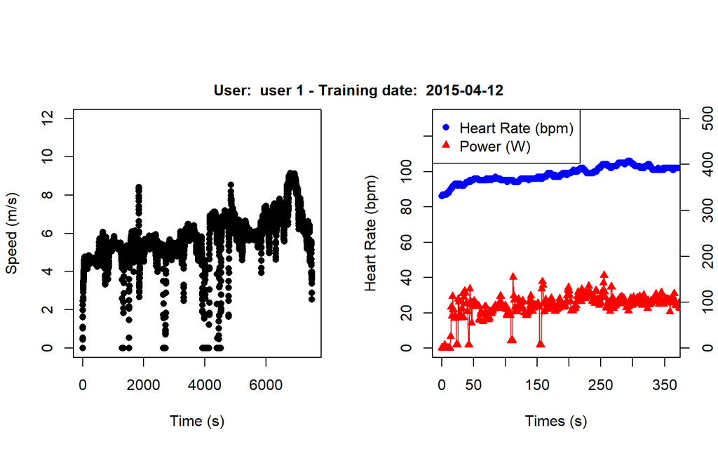

```r
par(mfrow = c(1,2),oma = c(0, 0, 2, 0))

plot(echantillon$time_s,echantillon$speed,xlab = "Time (s)" ,ylab = "Speed (m/s)",pch = 16, ylim =  c(0,12))

plot(echantillon$time_s, echantillon$hr,xlab = "Times (s)", ylab = "Heart Rate (bpm)", type = "b", pch = 16, xlim =  c(0,360), ylim = c(0,130), col = "blue")

par(new=TRUE)

plot(echantillon$time_s, echantillon$po,xlab = "", ylab = "", pch = 17, axes = FALSE, xlim = c(0,360), ylim = c(0,500), col = "red")

axis(4, ylim = c(0,500))
mtext("Power (W)", side = 4, line = 4)

lines(echantillon$time_s, echantillon$po, col = "red")

legend("topleft", legend = c("Heart Rate (bpm)", "Power (W)"), pch = c(16, 17), col = c("blue", "red"))

date <- as.Date(echantillon$timestamp)
mtext(paste("User: ", unique(echantillon$user), "- Training date: ", unique(date)),
      side = 3, outer = TRUE, line = -3.5, font = 2)
```

# Partie B : Modélisation.

## Question 1.

La fonction `rythme_cardiaque()` représente le premier modèle : $HR = HR_{base} + a (1-e^{-b P})$

Elle prend en argument les variables suivantes:

- **puissance** : la puissance exercée (en Watts) ;
- **HRbase** : le rythme cardiaque au repos ou minimum ;
- **a** : un coefficient qui représente l’amplitude maximale de l’augmentation du rythme cardique du à l’effort ;
- **b** : constance de proportionalité qui définit la sensibilité du rythme cardique à l’augmentation de la puissance.

```r
rythme_cardiaque <- function(puissance, HRbase, a, b)
  {
  HR <- HRbase + a * (1 - exp(-b * puissance))
  return(HR)
}
```

## Question 2.

La simulation ci-dessous nous permet de trouver le rythme cardiaque en fonction de la puissance exercée, sachant que l’on a un vecteur de puissance avec des valeurs allant de 0 à 450 Watts. Ensuite, grâce à la fonction prédéfinie `rythme_cardiaque()` (voir question 1), les rythmes cardiaques correspondants sont calculés.

Nous devions rajouter du bruit, ce bruit suit une distribution normale avec une moyenne de 0 et une variance de 100.

Enfin, les résultats bruités sont stockés dans la variable `simul_hr`.

```r
# Données :
simul_po <- seq(0,450)
HRbase <- 50
a <- 130
b <- 0.05

# Simulation sans bruit :

sans_bruit <- rythme_cardiaque(simul_po,HRbase,a,b)

# Simulation avec bruit :

bruit <- rnorm(length(simul_po), mean = 0, sd = sqrt(100))
simul_hr <- sans_bruit + bruit

# Premiers résultats :

head(simul_hr)
```

```
## [1] 42.71805 53.67316 73.10652 75.33785 60.53330 86.37553
```

## Question 3.

La fonction `rythme_cardiaque_modele_2()` représente le second modèle : $HR = HR_{base} + (HR_{max}-HR_{base}) \left(\frac{P}{P_{max}}\right)^n$

Elle prend en argument les variables suivantes:

- **puissance** : la puissance produite par l’athlète (en Watts) ;
- **HRbase** : le rythme cardiaque au repos ou minimum ;
- **HRmax** : le rythme cardiaque maximal ;
- **Pmax** : la puissance maximale ;
- **n** : un coefficient d’adaptation.

```r
rythme_cardiaque_modele2 <- function(puissance, HRbase, HRmax, Pmax, n) {
  HR <- HRbase + (HRmax - HRbase) * (puissance / Pmax)^n
  return(HR)
}
```

## Question 4.

Pour cette question, nous nous sommes seulement appuyés sur la formule de la Mean Squared Error (MSE) : $\frac{1}{n} \sum_{i=1}^n (Y_i - \hat{Y}_i)^2$, où $Y_i$ sont les observations et $\hat{Y}_i$ les prédictions.

```r
calculer_MSE <- function(observations, predictions) {
  mse <- mean((observations - predictions)^2)
  return(mse)
}
```

## Question 5.

Ce code a pour objectif d’estimer les valeurs optimales des paramètres du modèle 2 (`HRmax`, `Pmax`, et `n`) en minimisant le Mean Squared Error (`MSE`) entre les valeurs simulées (`simul_hr`) et les prédictions calculées par le modèle.

Nous avons donc, dans un premier temps, construit `MSE_min`, en utlisant :

- Les paramètres du modèle en entrée (`HRmax`, `Pmax`, et `n`).
- Les prédictions obtenues via la fonction `rythme_cardiaque_modele2()`.
- Les données observées simulées (`simul_hr`).

A noter que nous avons utilisé plusieurs points de départ pour éviter les optima locaux :

- Valeur maximale possible pour HRmax et Pmax ;
- Valeur minimal possible pour HRmax et Pmax ;
- Moyenne estimée des paramètres (*cf.* statistiques descriptives de la partie A) ;
- Paramètre choisi au hasard.

```r
MSE_min <- function(params) {
  HRmax <- params[1]
  Pmax <- params[2]
  n <- params[3]
  predictions <- rythme_cardiaque_modele2(simul_po, HRbase, HRmax, Pmax, n)
  mse <- calculer_MSE(simul_hr, predictions)
  return(mse)
}


parametres_initiaux1 <- c(133, 384, 1)
resultat_nlm1 <- nlm(MSE_min, p = parametres_initiaux1)

parametres_initiaux2 <- c(86, 1, 1)
resultat_nlm2 <- nlm(MSE_min, p = parametres_initiaux2)

parametres_initiaux3 <- c(108.82, 84.97, 1)
resultat_nlm3 <- nlm(MSE_min, p = parametres_initiaux3)

parametres_initiaux4 <- c(120,100 , 1)
resultat_nlm4 <- nlm(MSE_min, p = parametres_initiaux4)

resultat_nlm1
```

```
## $minimum
## [1] 229.6225
##
## $estimate
## [1] 187.4006072 398.4351300   0.1160932
##
## $gradient
## [1] -2.740093e-06  6.898862e-06  3.296350e-04
##
## $code
## [1] 2
##
## $iterations
## [1] 15
```

```r
resultat_nlm2
```

```
## $minimum
## [1] 380.8911
##
## $estimate
## [1] 85.9963921  1.1444223  0.2386726
##
## $gradient
## [1] -11.431092  85.823224   1.680256
##
## $code
## [1] 2
##
## $iterations
## [1] 10
```

```r
resultat_nlm3
```

```
## $minimum
## [1] 229.6225
##
## $estimate
## [1] 161.1152971  63.9799611   0.1160946
##
## $gradient
## [1]  3.212354e-08 -4.349217e-08  5.288712e-06
##
## $code
## [1] 1
##
## $iterations
## [1] 22
```

```r
resultat_nlm4
```

```
## $minimum
## [1] 229.6225
##
## $estimate
## [1] 164.7530305  84.4407057   0.1160946
##
## $gradient
## [1]  6.115825e-07 -1.245341e-07  7.163251e-05
##
## $code
## [1] 1
##
## $iterations
## [1] 22
```

## Question 6.

Voici le code pour la construction de notre graphique. on a fait l’hypothèse que la meilleur MSE vient de la moyenne estimé des paramètres.

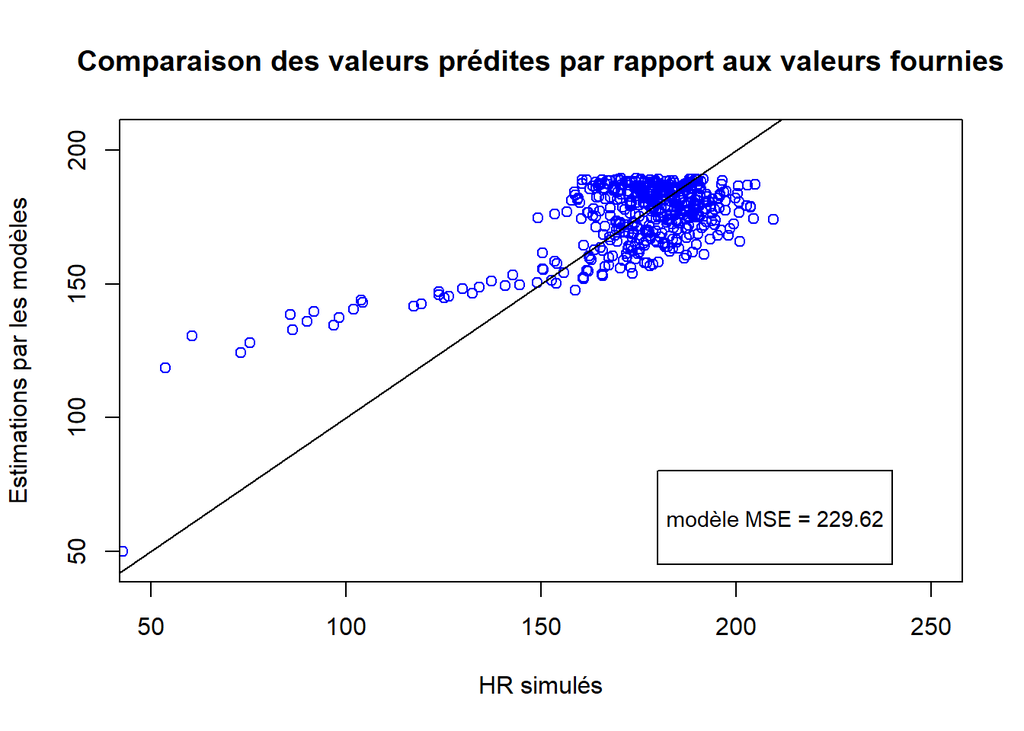

```r
HRmax_opt <- resultat_nlm3$estimate[1]
Pmax_opt <- resultat_nlm3$estimate[2]
n_opt <- resultat_nlm3$estimate[3]
meilleur_prediction <- rythme_cardiaque_modele2(simul_po, HRbase, HRmax_opt, Pmax_opt, n_opt)
mse_opt <- calculer_MSE(simul_hr, meilleur_prediction)


#Graphique
plot(simul_hr, meilleur_prediction, xlab = "HR simulés", ylab = "Estimations par les modèles",main = "Comparaison des valeurs prédites par rapport aux valeurs fournies", col = "blue", xlim = c(50, 250), ylim = c(45,205))
abline(a = 0, b = 1, col = "black")
rect(xleft = 180, ybottom = 45, xright = 240, ytop = 80, border = "black", col = "white")
text(x = 210, y = 62.5,labels = paste("modèle MSE =", round(mse_opt, 2)), cex = 0.9, col = "black")
```